# 4. Greedy Algorithms II

# Min-cost arborescence

## Arborescence

**Def**. Given a digraph $G = (V, E)$ and a root $r \in V$, an arborescence (rooted at $r$) is a subgraph $T = (V, F)$ such that

- T is a spanning tree of $G$ if we ignore the direction of edges.
- There is a (unique) directed path in $T$ from $r$ to each other node $v \in V$.

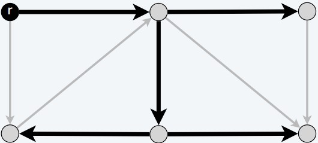

## Quiz: Arborescence

Which of the following are properties of arborescence rooted at r?

**A**. No directed cycles.  
**B**. Exactly $n − 1$ edges.  
**C**. For each $v \ne r$ : $indegree(v) = 1$.  
**D**. All of the above.

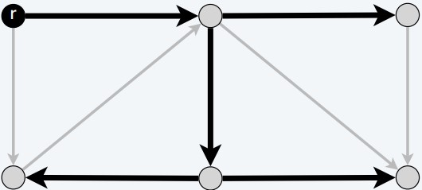

## Arborescence: property

**Proposition**. A subgraph $T = (V, F)$ of $G$ is an arborescence rooted at $r$ iff $T$ has no directed cycles and each node $v \ne r$ has exactly one entering edge.  
**Pf**.

$\Rightarrow$ If $T$ is an arborescence, then no (directed) cycles and every node $v \ne r$ has exactly one entering edge: the last edge on the unique $r \leadsto v$ path.

$\Leftarrow$ Suppose $T$ has no cycles and each node $v \ne r$ has one entering edge.

- To construct an $r \leadsto v$ path, start at $v$ and repeatedly follow edges in the backward direction.
  - Since $T$ has no directed cycles, the process must terminate.
  - It must terminate at $r$ since $r$ is the only node with no entering edge.

## Min-cost arborescence problem

**Problem**. Given a digraph $G$ with a root node $r$ and edge costs $c_e \ge 0$, find an arborescence rooted at $r$ of minimum cost.

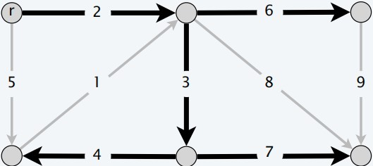

**Assumption 1**. All nodes reachable from $r$.

**Assumption 2**. No edge enters $r$ (safe to delete since they won’t help).

## Quiz: Minimum spanning arborescence

A min-cost arborescence must …

**A**. Include the cheapest edge.  
**B**. Exclude the most expensive edge.  
**C**. Be a shortest-paths tree from $r$.  
**D**. None of the above.

D. See below.

## A sufficient optimality condition

**Property**. For each node $v \ne r$, choose a cheapest edge entering $v$ and let $F^\ast$ denote this set of $n – 1$ edges. If $(V, F^\ast)$ is an arborescence, then it is a min-cost arborescence.  
**Pf**. An arborescence needs exactly one edge entering each node $v \ne r$ and $(V, F^\ast)$ is the cheapest way to make each of these choices.

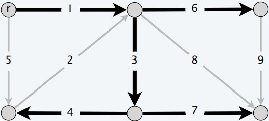

## A sufficient optimality condition

**Property**. For each node $v \ne r$, choose a cheapest edge entering $v$ and let $F^\ast$ denote this set of $n – 1$ edges. If $(V, F^\ast)$ is an arborescence, then it is a min-cost arborescence.  
**Note**. $F^\ast$ may not be an arborescence (since it may have directed cycles).

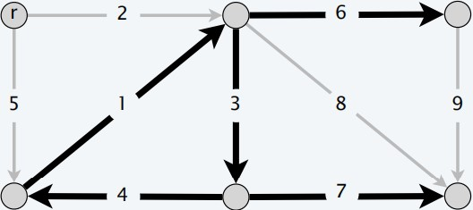

## Reduced costs

**Def**. For each $v \ne r$, let $y(v)$ denote the min cost of any edge entering $v$.  
Define the **reduced cost** of an edge $(u, v)$ as $cʹ(u, v) = c(u, v) – y(v) \ge 0$.

**Observation**. $T$ is a min-cost arborescence in $G$ using costs $c$ iff $T$ is a min-cost arborescence in $G$ using reduced costs $cʹ$.  
**Pf**. For each $v \ne r$: each arborescence has exactly one edge entering $v$.

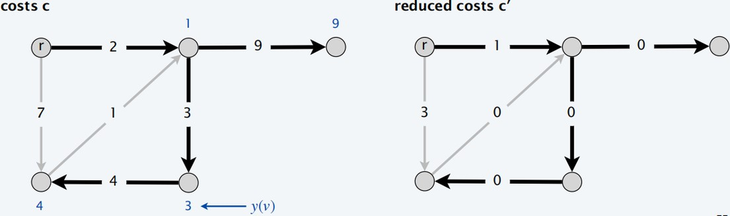

## Edmonds branching algorithm: intuition

**Intuition**. Recall $F^\ast$ = set of cheapest edges entering $v$ for each $v \ne r$.

- Now, all edges in $F^\ast$ have 0 cost with respect to reduced costs $cʹ(u, v)$.
  - If $F^\ast$ does not contain a cycle, then it is a min-cost arborescence.
  - If $F^\ast$ contains a cycle $C$, can afford to use as many edges in $C$ as desired.
    - *Contract* edges in $C$ to a supernode (removing any self-loops).
    - Recursively solve problem in contracted network $Gʹ$ with costs $cʹ(u, v)$.

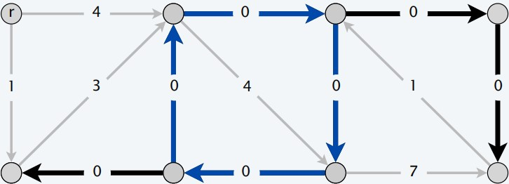

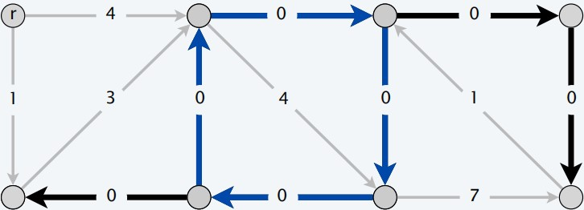

## Edmonds branching algorithm

1. FOREACH $v \ne r$:
   1. $y(v)$ = min cost of any edge entering $v$;
   2. $cʹ(u, v) = cʹ(u, v) – y(v)$ for each edge $(u, v)$ entering $v$;
2. FOREACH $v \ne r$: choose one 0-cost edge entering $v$ and let $F^\ast$ be the resulting set of edges;
3. IF ($F^\ast$ forms an arborescence): RETURN $T = (V, F^\ast)$;
4. ELSE:
   1. $C$ = directed cycle in $F^\ast$;
   2. Contract $C$ to a single supernode, yielding $Gʹ = (Vʹ, Eʹ)$;
   3. $Tʹ$ = `EDMONDS-BRANCHING`($Gʹ$, $r$, $cʹ$);
   4. Extend $Tʹ$ to an arborescence $T$ in $G$ by adding all but one edge of $C$;
   5. RETURN $T$;

## Demo: Edmonds branching algorithm

## Edmonds branching algorithm: all done?

**Q**. What could go wrong?  
**A**. Contracting cycle $C$ places extra constraint on arborescence.

- Min-cost arborescence in $Gʹ$ must have exactly one edge entering a node in $C$ (since $C$ is contracted to a single node)
  - But min-cost arborescence in $G$ might have several edges entering $C$.

## Edmonds branching: key lemma

**Lemma**. Let $C$ be a cycle in $G$ containing only 0-cost edges. There exists a min-cost arborescence $T$ rooted at $r$ that has exactly one edge entering $C$.  
**Pf**.

**Case 0**. $T$ has no edges entering $C$.

- Since $T$ is an arborescence, there is an $r \leadsto v$ path for each node $v$
  - at least one edge enters $C$.

**Case 1**. $T$ has exactly one edge entering $C$.

- $T$ satisfies the lemma, done.

**Case 2**. $T$ has two (or more) edges entering C.

- We construct another min-cost arborescence $T^\ast$ that has exactly one edge entering $C$.

## Edmonds branching: key lemma (cont.)

**Case 2 construction of $T^\ast$**.

- Let $(a, b)$ be an edge in $T$ entering $C$ that lies on a shortest path from r.
- We delete all edges of $T$ that enter a node in $C$ except $(a, b)$.
- We add in all edges of $C$ except the one that enters $b$.

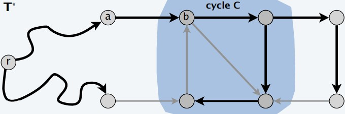

**Claim**. $T^\ast$ is a min-cost arborescence.

- The cost of $T^\ast$ is at most that of $T$ since we add only 0-cost edges.
- $T^\ast$ has exactly one edge entering each node $v \ne r$.
- $T^\ast$ has no directed cycles.

## Edmonds branching: analysis

**Theorem**. [Chu–Liu 1965, Edmonds 1967] The greedy algorithm finds a min-cost arborescence.  
**Pf**. [ by strong induction on number of nodes ]

- If the edges of $F^\ast$ form an arborescence, then min-cost arborescence.
- Otherwise, we use reduced costs, which is equivalent.
- After contracting a 0-cost cycle $C$ to obtain a smaller graph $Gʹ$, the algorithm finds a min-cost arborescence $Tʹ$ in $Gʹ$ (by induction).
- Key lemma: there exists a min-cost arborescence $T$ in $G$ that corresponds to $Tʹ$.

**Theorem**. The greedy algorithm can be implemented to run in $O(m n)$ time.  
**Pf**.

- At most $n$ contractions (since each reduces the number of nodes).
- Finding and contracting the cycle $C$ takes $O(m)$ time.
- Transforming $Tʹ$ into $T$ takes $O(m)$ time.

## Edmonds branching: better bound

**Theorem**. [Gabow–Galil–Spencer–Tarjan 1985] There exists an $O(m + n \log n)$ time algorithm to compute a min-cost arborescence.